# Concurrence Imparfaite 2 : Les oligopoles

Simon Jean

simon.jean@agroparistech.fr

AgroParisTech - CIRED - PSAE

# Introduction

## Rappels : concurrence pure et parfaite a concurrence imparfaite - rappels

- Concurrence *pure et parfaite*:
  - Les producteurs sont des *preneurs de prix*, ils *réagissent au marché*, sans l’impacter, et agissent en maximisant leur profit
  - L’offre est déterminée par $p = Cm(q)$ i.e. on s’arrête de produire lorsque le coût marginal dépasse le prix, et le prix de vente reflète le coût marginal de la dernière unité produite
  - Cette situation maximise le **surplus collectif**, incluant celui du consommateur

## Rappels : le monopole

- Monopole :
  - Le producteur est *faiseur de prix*, en fonction de l’élasticité de la demande, il fixe le prix et les quantités offertes sur le marché pour maximiser son profit
  - Il tarifie au delà du coût marginal, le prix est tel que $p= \frac{1}{1 +\eta}Cm(q)$ où $\eta$ est la réciproque de l’elasticité de la demande, et $\frac{1}{1+ \eta}$ est le *taux de markup*
- Comme il tarifie au delà du coût marginal:
  - Moins de quantités sont consommées
  - A un plus haut prix
  - Causant une perte de surplus collectif et une *redistribution* du surplus des consommateurs vers l’entreprise

## Les oligopoles

**Définition**

Les **oligopoles** sont des situations de *marché* où un nombre *fini* et **restreint** d’entreprises se partagent le marché.

Au milieu entre la concurrence pure et parfaite où il y’a $n \to \infty$ firmes et le monopole où il y a $n=1$ firme

Exemples:

- Téléphonie en France : 4 acteurs
- Voitures : Renault-Nissan + PSA > 60% marché
- Grande distribution : 6 acteurs pour 92%
- Eau en bouteille

## Pourquoi une analyse spécifique aux oligopoles?

Imaginez une entreprise en situation de *monopole*, du fait d’une barrière technologique (i.e. un brevet, ou simplement, d’autres entreprises n’ont pas la technologie)

- Un nouveau concurrent arrive sur le marché
- L’ancien monopole doit **s’adapter** et **réagir** à l’entrée du concurrent, et vice versa pour le concurrent
- On a ce qu’on appelle des **interactions stratégiques** i.e. une situation où le profit des agents **dépend** des actions **des autres agents**

On se focalise aujourd’hui sur les **duopoles**, i.e. situations à 2 entreprises

## Différents types de duopoles en fonction des caractéristiques

- *Duopoles* avec des produits et une information **homogènes** :
  - Même produits
  - Connaissance *parfaite* des coûts de production de tout le monde
- Dans le cadre de *jeux* (cf. théorie des jeux):
  - Simultanés
  - Séquentiels
- avec différents *variables stratégiques* :
  - Les entreprises fixent leurs **quantités**
  - Les entreprises fixent leurs **prix**
- Avec une **fonction de demande inverse** : $P(Q)= P(Q_A+Q_B)$ avec $P'(Q)<0$

## Notion d’équilibre

On se focalise sur **l’équilibre des jeux**, c’est à dire une situation où l’on ne bouge plus

Qu’est ce que ça veut dire, en économie, ou dans un jeu?

**Définition**

Un **équilibre de Nash** est une allocation où aucun agent n’a **unilatéralement** intérêt à dévier

- On peut le chercher avec des **fonctions de meilleures réponses**
- Ou alors, en comparant les différentes stratégies, avec des matrices de gains

# I. Le duopole de Cournot

## Le duopole de Cournot - théorie

Deux entreprises $A$ et $B$ se font concurrence en *quantités* : elles choissent combien d’unités mettre sur le marché, pas les prix.

- Intuition sur le comportement?
  - Plus il y a de quantités, plus le prix baisse: il y a une **interaction** par le prix $P(Q) = P(Q_1 + Q_2)$
  - *Plus* mon concurrent produit, plus il baisse les prix (mais augmente son volume et peut-être ses recettes totales), *mais* j’en souffre *donc* je produis moins
  - *Moins* mon concurrent produit, plus les prix sont hauts (mais son volume est bas, et ses recettes totales baissent peut être) *mais* j’en bénéficie *donc* je produis plus
- *Un intérêt commun à réduire la production*

## Le duopole de Cournot - théorie

- Pour chaque entreprise :
  - $CT_i(q_i)$ est le coût total
  - $Cm_i(q_i) = CT_i'(q_i)$ est le coût marginal de production
  - $q_j^E$ est l’anticipation relative à la production du concurrent
  - Le profit s’écrit : $\Pi_i(q_i; \mathbf{q_j^E}) = P(Q)q_i - CT(q_i) = P(q_i+q_j^E)q_i - CT(q_i)$
  - Chaque entreprise maximise son profit<sup>1</sup> :
    $$\begin{align}
    \Pi_i'(q_i;\mathbf{q_j^E}) &= P'(q_i+q_j^E)q_i + P(q_i+q_j^E) - Cm(q_i) = 0\\
    & \Rightarrow q_i^* = q_i(q_j^E)
    \end{align}$$
[^1]: La condition du premier ordre suffit sous réserve que les conditions de second ordre tiennent

## Le duopole de Cournot - théorie

- Chaque entreprise aboutit à une **fonction de réaction** i.e. fonction de *meilleure réponse* conditionnellement à la production attendue de son concurrent
  - Quel est le signe de $q_i^{*'}(\mathbf{q_j^E})$ ?
  - On peut prouver que $q_i^{*'}(\mathbf{q_j^E})<0$, conformément aux intuitions
- Comment trouver l’équilibre?
  - Ici, on regarde le *long terme* : une convergence, où il n’y a plus intérêt de bouger c’est à dire **un équilibre de Nash**  
    Comment?
- Sous la forme d’un jeu *simultané* :
  - On décide une bonne fois pour toute avec toute l’information
  - En résolvant un système d’équations simultanées

## Le duopole de Cournot - Exemple

[figure not shown]

Vous trouverez plus d’infographie sur [Statista](https://fr.statista.com/graphique-du-jour/)

- On **simplifie**, on prend deux entreprises, $A$ et $B$ et:
  - On suppose que leur coûts totaux de production sont linéaires: $CT_i(q_i) = cq_i$
  - On normalize la demande inverse : $P(Q) = 1 - (q_A + q_B)$
  - Le profit est donc : $\Pi_i(q_i, \mathbf{q_j^E}) = q_i (1 - c - (q_i+ \mathbf{q_j^E}))$

## Le duopole de Cournot - exemple

Chacun maximise son profit, en prenant les actions de son concurrent comme donnée, anticipée:
$$\begin{align}
\Pi'(q_i) = 0 &\iff (1 - c - 2q_i - \mathbf{q_j^E})=0\\
&\iff q_i^* = \frac{1 - c - \mathbf{q_j^E}}{2}
\end{align}$$

La stratégie du concurrent est *connaissance commune* :

- Chaque entreprise connaît la stratégie de l’autre, et peut remplacer $\mathbf{q_j^E}$ par $q_j^*$
- Et résout un système d’équation simultanées :

## Le duopole de Cournot - exemple

$$\begin{align}
q_A^{*C} = \frac{1 - c - \mathbf{q_B^E}}{2}\\
q_B^{*C} = \frac{1 - c - \mathbf{q_A^E}}{2}
\end{align}$$
Donc :
$$q_A^* = q^*_B = \frac{1-c}{3}$$

## Le duopole de Cournot - exemple

$$\begin{align}
q_A^* = \frac{1 - c - \mathbf{q_B^E}}{2}\\
q_B^* = \frac{1 - c - \mathbf{q_A^E}}{2}
\end{align}$$
Donc :
$$q_A^* = q^*_B = \frac{1-c}{3}$$

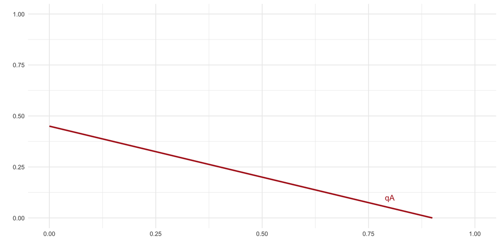

## Le duopole de Cournot - exemple

$$\begin{align}
q_A^* = \frac{1 - c - \mathbf{q_B^E}}{2}\\
q_B^* = \frac{1 - c - \mathbf{q_A^E}}{2}
\end{align}$$
Donc :
$$q_A^* = q^*_B = \frac{1-c}{3}$$

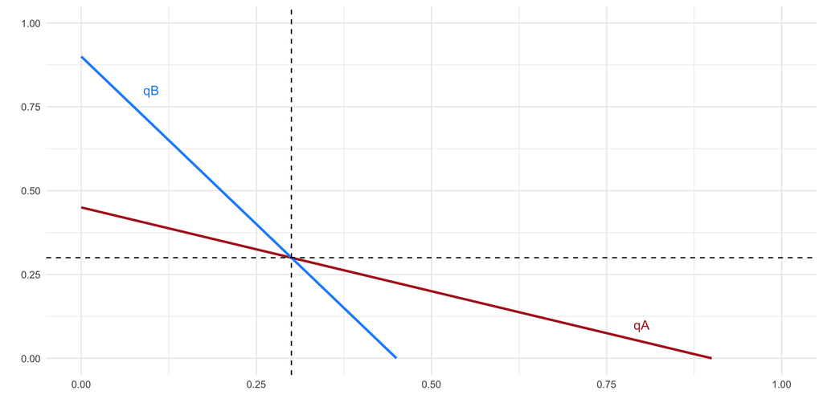

## Le duopole de Cournot

- Dans ce cas, il y a un profit réalisé, positif: $\Pi_i= \left(\frac{1-c}{3}\right)^2$
  - On y reviendra
- Dans la pratique, on peut avoir un autre type de cas, où une firme domine :
  - Une firme est présente depuis longtemps
  - L’autre arrive, et n’a pas encore toutes les capacités de production installées etc.
- Cela donne lieu à un jeu *séquentiel* dans le cadre du duopole de *Stackelberg*

# II. Le duopole de Stackelberg

## Théorie

- Cadre de jeu **séquentiel** donc :
  - Un premier joueur choisit sa production
  - Le second suit  
    Comment?
- On se rappelle que toute l’information est partagée:
  - Le premier joueur connaît la *fonction de réaction* du second, et l’intègre dans sa décision  
    Méchanisme **d’induction à rebours** : on remonte du dernier choix possible au premier pour résoudre le jeu
  - Le second observe la quantité produite et s’adapte

## Théorie

Si on suppose que l’entreprise A est leader, elle maximise son profit $\Pi_A = p(q_A, q_B^*(q_A))q_A - CT(q_A)$

On a :
$$\frac{\partial \Pi_A}{\partial q_A} = 0 \Rightarrow q_A^*$$

Et *in fine* $q_B(q_A^*) = q_B^*$

## Exemple

On suppose maintenant que la firme A, leader, est plus efficiente à produire :

- $CT_A(q_A) = \frac{1}{2}q_A^2$
- $CT_B(q_B) = 2q_B^2$
- Etape 1 : on détermine la fonction de réaction de l’entreprise suiveuse :
  $$\frac{\partial }{\partial q_B}((1 - q_A - q_B)q_B - 2q_B^2) = 1 - q_A - 6 q_B^2 = 0 \Rightarrow q_B(q_A) = \frac{1 - q_A}{6}$$

## Exemple

- Etape 2 : la firme A, leader, intègre cela dans sa décision : $\Pi_A(q_A) = \left(1 - q_A - \frac{1-q_A}{6} \right)q_A - \frac{1}{2}q_A^2$
  $$\Pi_A'(q_A)=0 \Rightarrow q_A^{*S} = \frac{5}{16}= 0.3125$$
- Etape 3 : la firme B réagit effectivement et produit : $q_B = \frac{11}{96}\approx 0.1145$

## Conclusion

- La firme B produit moins que la firme A et fait moins de profit (double effet dans l’exemple):
  - Avantage du premier joueur
  - Différence de coût
- On effectue une analyse statique et certaine ici:
  - Dans les faits, les firmes **anticipent** les actions de leurs concurrents
  - Ces anticipations se fondent sur des *annonces* et leur *crédibilité*
  - Une firme leader doit correctement anticiper la réaction de la firme suiveuse, qui doit elle même faire des annonces crédibles
  - Les annonces peuvent ne pas être crédibles : le leader agit alors sur la base de ses propres estimations

# III. Le duopole de Bertrand

## Set-up

- Jeu symétrique
- La variable stratégique ici est **le prix**: au lieu des quantités, les entreprises fixent les prix auxquels elles vendent, et laisse s’ajuster les quantités produites
  - Cela suppose quoi?  
    De pouvoir produire autant que ce qui est demandé
- Elles se font concurrence pour récupérer des parts de marché sur un produit **homogène**

## Résolution

- On revient à un coût total de production linéaire, où $c$ est le coût marginal de production des deux entreprises
- On travaille cette fois avec une fonction de demande $D_i(p_i, p_j)$ et le profit est
  $$\Pi_i = (p_i - c)D(p_i, p_j)$$
- On est sur un bien homogène (les consommateurs ne font pas la différence), comment va se caractériser la demande?
  - Effectivement, si $p_i<p_j$, $D_i(p_i, p_j) = D(p_i)$
  - Si $p_i = p_j$, $D_i(p_i, p_j)= D_j(p_j, p_i) = \frac{1}{2}D(p_i)$
  - Finalement, si $p_i>p_j$, alors $D_i(p_i, p_j)=0$

## Résolution

- On a donc les profits suivants :
  - Effectivement, si $p_i<p_j$, $\Pi_i = D(p_i)(p_i -c)$
  - Si $p_i = p_j$, $\Pi_i= \frac{1}{2}D(p_i)(p_i -c)$
  - Finalement, si $p_i>p_j$, alors $\Pi_i=0$
- Comment trouver **l’équilibre de Nash**?
  - Méthode : Comparer les payoffs
- Si $p_A>p_B>c$:
  - $D_A = 0 \Rightarrow \Pi_A=0$
  - A peut améliorer son profit en faisant $p_A'<p_B$ et récupérant la demande  
    Ce n’est donc pas un équilibre
  - De façon symmétrique pour $B$, bien entendu

## Résolution

- Si $p_A >p_B = c$
  - $\Pi_A=\Pi_B=0$
  - B peut améliorer son profit en faisant $p_B' = p_A-\epsilon$, où $c<p_B'<p_A$  
    Ce n’est donc pas un équilibre
- Le seul cas qui reste est $p_A=p_B=c$
  - Si A augmente son prix, il perd toute la demande, pareil pour B
  - Si B baisse son prix, il fait un profit négatif, pareil pour B
  - Il n’ya donc pas d’intérêt à dévier

## Conclusion

**Le paradoxe de Bertrand**

En situation de duopole, si la concurrence se fait en prix, l’allocation d’équilibre est identique à l’allocation concurrentielle

- En termes de politique publique, dans ce cas, l’Etat n’aurait pas besoin d’agir, de réguler les marchés
- Pour les entreprises, la guerre des prix implique pas de profit  
  Quelles sont les marges pour en sortir?
- Comment résoudre le paradoxe?
  - Avec des produits différenciés
  - Des interactions répétées
  - De l’information imparfaite (*Paradoxe de Diamond*)
  - Des contraintes de capacité

## Conclusion

**Le paradoxe des marchés contestables, Beaumol**

L’allocation de concurrence peut prévaloir même lorsque les conditions de la concurrence ne sont pas réunies, si le marché est **contestable**, si la menace d’un nouvel entrant est crédible

Il faut maintenir les barrières à l’entrée basses pour éviter les oligopoles qui surtarifient

# IV. Les collusions

## Collusions

- On a vu des jeux **non-coopératifs**, qui mènent à des profits inférieurs à celui du monopole  
  $\Rightarrow$ Pourquoi ne pas s’allier?
- Certaines firmes vont parfois s’allier, explicitement ou implicitement :
  - Cartel de l’OPEP
  - Cartel du linoleum
- L’identification des cartels est difficile :
  - Les coûts sont difficiles à voir, l’état à du mal a les voir
  - Il y a des outils qui indiquent, mais ne suffisent pas à prouver économiquement : parts de marché, corrélations de prix et fluctuations etc.

## Collusions

- C’est strictement **interdit** (modulo quelques exceptions) dans le cadre du droit de la concurrence (Articles 101,102 et 107-109 du TFUE)
- Problématiques de stabilité des collusions:
  - Il peut y avoir un intérêt à dévier pour augmenter ses profits avant de se faire attraper: si tout le monde réduit la production, on bénéficie de produire plus à la marge et de dévier de la stratégie commune
  - Il y a un intérêt à dénoncer en premier un cartel pour bénéficier du *programme de clémence*

# V. La concurrence monopolistique

## Définition et enjeux

- Les produits ne sont plus homogènes : on a différentes variétés (i.e. différenciation horizontale)
- Par conséquent, chaque entreprise a un *pouvoir de marché* sur son segment, qui est limité, là où elle faisait face à une demande horizontale en concurrence pure et parfaite
- La limite vient de la substituabilité avec d’autres produits proches : on utilise des fonctions de demande qui prennent en compte la variété et les substitutions imparfaites
- La différenciation explique le commerce *intrabranche* entre pays (voir les travaux de P.Krugman) (60% des échanges): la France exporte des voitures vers l’Allemagne et réciproquement

# Conclusion

## Qui s’applique quand?

- Il est parfois difficile de savoir qui s’applique quand, quel modèle pour analyser quelle situation
- Variable clé : l’ajustabilité des capacités de production
  - Si la capacité de production s’ajuste facilement, on peut s’attendre à une concurrence en prix  
    Marchés de services
  - Si le contraire est vrai, la concurrence à la Cournot semble plus appropriée  
    Marchés de biens

## Faut il intervenir?

- Les pratiques anticoncurrentielles nuisent au consommateur :
  - Prix plus élevés
  - Potentiellement des effets sur l’emploi
  - Et des effets négatifs sur l’innovation
- On l’a vu, le profit est inversement relié à la concurrence : les entreprises essaient d’y échapper
  - Parfois par des processus “vertueux” : différenciation, innovation etc
  - Mais aussi par des moyens moins vertueux, comme la collusion ou l’usage d’un pouvoir de marché
- C’est le rôle de la **politique de la concurrence** que de réguler cela.